# RNA-seq example workflow

In this document we will go through an entire RNA-seq analysis workflow, from raw read files to statistical interpretation. We will use an example data set, described below. Note that to make things simpler, all commands will be run from inside `R`, but that everything that is within a `system()` call in fact invokes a “system command”, which is run outside of `R` (equivalent to running the command from the command line).

## Set some paths

The first thing we need to do is to set paths to the software that will be used and to input and output folders, where data will be read and written.

```r
## Set input data directory. This is the path to the unpacked STA426_2017_RNAseq_input folder
## data_dir <- "~/Dropbox/teaching_material/STA426lecture2017/for_students_input"
## If you are running from the computers in Y11-J-05, use the following path:
data_dir <- "/Volumes/GroupsBio/Sta_426/RNAseq_workflow_files/input"
data_dir <- "/home/mholub/RNAseq_temp/input"

## Set output directory. If you want to generate output, it should be a directory where
## you have writing permission. If you just want to read the pre-generated output,
## it is the path to the unpacked STA426_2017_RNAseq_output folder
## output_dir <- "~/Dropbox/teaching_material/STA426lecture2017/for_students_output"
## If you are running from the computers in Y11-J-05 and only want to read
## results, use the following path:
## output_dir <- "/Volumes/GroupsBio/Sta_426/RNAseq_workflow_files/output"
output_dir <- "~/Desktop/STA426_2017"
output_dir <- "/home/mholub/RNAseq_temp/output"
```

```r
## Set paths to the software we will use. This will depend on your system. If you want to
## use the pre-generated output, you don't need to set these

## FastQC
## path_to_fastqc <- "~/Documents/Software/FastQC_v0.11.5/fastqc"
## For computers in Y11-J-05:
path_to_fastqc <- "/usr/local/course/bin/fastqc/fastqc"
path_to_fastqc <- "/home/mholub/Software/FastQC/fastqc"

## HISAT2-build
## path_to_hisat2_build <- "~/Documents/Software/hisat2-2.0.4/hisat2-build"
## For computers in Y11-J-05:
path_to_hisat2_build <- "/usr/local/course/bin/hisat2-2.0.4/hisat2-build"
path_to_hisat2_build <- "/home/mholub/Software/hisat2-2.1.0/hisat2-build"

## HISAT2
## path_to_hisat2 <- "~/Documents/Software/hisat2-2.0.4/hisat2"
## For computers in Y11-J-05:
path_to_hisat2 <- "/usr/local/course/bin/hisat2-2.0.4/hisat2"
path_to_hisat2 <- "/home/mholub/Software/hisat2-2.1.0/hisat2"

## samtools
## path_to_samtools <- "/usr/local/bin/samtools"
## For computers in Y11-J-05:
path_to_samtools <- "/usr/local/course/bin/samtools"
path_to_samtools <- "/home/mholub/Software/samtools/bin/samtools"

## Salmon
## Note that if you are running Salmon on a mac, you may need to explicitly
## point it to the dynamic libraries as shown below. The
## DYLD_FALLBACK_LIBRARY_PATH should be the "lib" folder obtained with the
## downloaded binary
## path_to_salmon <- "DYLD_FALLBACK_LIBRARY_PATH=~/Documents/Software/Salmon-0.8.2_macOX_10.12/lib ~/Documents/Software/Salmon-0.8.2_macOX_10.12/bin/salmon"
## For computers in Y11-J-05:
path_to_salmon <- "DYLD_FALLBACK_LIBRARY_PATH=/usr/local/course/lib /usr/local/course/bin/salmon"
path_to_salmon <- "/home/mholub/Software/salmon/bin/salmon"
```

```r
## If you want to generate output in the output directory, create some
## necessary subfolders
system(sprintf("mkdir -p %s/airway_chr18", output_dir))
system(sprintf("mkdir -p %s/airway_chr18/reference_chr18/hisat2_index", output_dir))
```

## The example data set

The example data set comes from an RNA-seq experiment wherein airway smooth muscle cells were treated with dexamethasone (see [Himes 2014, PMID 24926665](https://www.ncbi.nlm.nih.gov/pubmed/24926665), data is deposited in Gene Expression Omnibus under accession GSE52778). Four human airway smooth muscle cell lines were treated with 1 micromolar dexamethasone for 18 hours. For each of the four cell lines, we have a treated and an untreated sample. All quantifications will be based on the Ensembl human reference genome, version GRCh37.75. Note that for a real analysis, you should typically use the most recent reference genome for your particular organism.

### Raw data

Raw reads typically come as fastq files. Here we investigate what such a file looks like by printing the first few lines.

```r
(cmd <- sprintf("head %s/airway_chr18/SRR1039508_chr18_1.fastq", data_dir))
```

```
## [1] "head /home/mholub/RNAseq_temp/input/airway_chr18/SRR1039508_chr18_1.fastq"
```

```r
system(cmd)
```

### QC of raw data

Raw data quality control is typically done to check for low-quality data, remaining adapters, contamination, etc. One of the most popular software packages to do this is [FastQC](http://www.bioinformatics.babraham.ac.uk/projects/fastqc/).

```r
(cmd <- paste0('chmod +x ', path_to_fastqc))
```

```
## [1] "chmod +x /home/mholub/Software/FastQC/fastqc"
```

```r
system(cmd)
(cmd <- paste0(path_to_fastqc, " -h"))
```

```
## [1] "/home/mholub/Software/FastQC/fastqc -h"
```

```r
system(cmd)
```

Since we have so called *paired-end* reads (each cDNA fragment was sequenced from both ends), we have two fastq files for each sample, which are run through FastQC separately.

```r
(cmd <- sprintf("%s -o %s/airway_chr18 %s/airway_chr18/SRR1039508_chr18_1.fastq",
                path_to_fastqc,
                output_dir,
                data_dir))
```

```
## [1] "/home/mholub/Software/FastQC/fastqc -o /home/mholub/RNAseq_temp/output/airway_chr18 /home/mholub/RNAseq_temp/input/airway_chr18/SRR1039508_chr18_1.fastq"
```

```r
system(cmd)
```

```r
(cmd <- sprintf("%s -o %s/airway_chr18 %s/airway_chr18/SRR1039508_chr18_2.fastq",
                path_to_fastqc,
                output_dir,
                data_dir))
```

```
## [1] "/home/mholub/Software/FastQC/fastqc -o /home/mholub/RNAseq_temp/output/airway_chr18 /home/mholub/RNAseq_temp/input/airway_chr18/SRR1039508_chr18_2.fastq"
```

```r
system(cmd)
```

#### If necessary, fix QC problems

Most commonly, this involves trimming away sequencing adapters. More rarely, very low-quality sequences are excluded or trimmed. Some software for trimming reads are [cutadapt](http://cutadapt.readthedocs.io/en/stable/guide.html), [Trimmomatic](http://www.usadellab.org/cms/?page=trimmomatic), [FASTX-toolkit](http://hannonlab.cshl.edu/fastx_toolkit/) and [TrimGalore!](https://www.bioinformatics.babraham.ac.uk/projects/trim_galore/)

## Reference files

Reference files are needed to infer the origin of the observed read sequences. There are several sources of such reference files, e.g. [Ensembl](http://www.ensembl.org/info/data/ftp/index.html), [UCSC](http://hgdownload.cse.ucsc.edu/downloads.html), or [iGenome](http://support.illumina.com/sequencing/sequencing_software/igenome.html). An alternative is [biomaRt](http://www.ensembl.org/biomart/martview). See a recent [tutorial](http://www.nxn.se/valent/2016/10/3/the-first-steps-in-rna-seq-expression-analysis-single-cell-and-other).

### Genomic sequence

The genomic sequence is typically provided in fasta format.

```r
system(sprintf("head %s/airway_chr18/reference_chr18/Homo_sapiens.GRCh37.75.dna.chromosome.18.fa",
               data_dir))
system(sprintf("wc -l %s/airway_chr18/reference_chr18/Homo_sapiens.GRCh37.75.dna.chromosome.18.fa",
               data_dir))
```

### Transcript sequences

Also the transcript sequences are typically stored in fasta format.

```r
system(sprintf("head %s/airway_chr18/reference_chr18/Homo_sapiens.GRCh37.75.cdna.chr18.fa",
               data_dir))
system(sprintf("wc -l %s/airway_chr18/reference_chr18/Homo_sapiens.GRCh37.75.cdna.chr18.fa",
               data_dir))
system(sprintf("grep '>' %s/airway_chr18/reference_chr18/Homo_sapiens.GRCh37.75.cdna.chr18.fa | wc -l",
               data_dir))
```

### Location of genomic features

The information about the genomic location of features such as exons or genes is typically provided in gtf (stricter, typically recommended) or gff format.

```r
system(sprintf("head %s/airway_chr18/reference_chr18/Homo_sapiens.GRCh37.75.chr18.gtf", data_dir))
```

## Genome alignment-based quantification approach

There are various aligners that can be used to find the most likely origin of each sequencing read on the genome, e.g. [HISAT2](https://ccb.jhu.edu/software/hisat2/index.shtml), STAR, or [TopHat2](https://ccb.jhu.edu/software/tophat/index.shtml). For genome alignment of RNA-seq data, it is important that the aligner allows gaps in the alignment (to accommodate reads spanning exon-exon junctions).

### Index reference genome for use with HISAT2

```r
(cmd <- paste0(path_to_hisat2_build, " -h"))
```

```
## [1] "/home/mholub/Software/hisat2-2.1.0/hisat2-build -h"
```

```r
system(cmd)
```

```r
(cmd <- sprintf("%s -p 1 %s %s",
                path_to_hisat2_build,
                paste0(data_dir, "/airway_chr18/reference_chr18/Homo_sapiens.GRCh37.75.dna.chromosome.18.fa"),
                paste0(output_dir, "/airway_chr18/reference_chr18/hisat2_index/Homo_sapiens.GRCh37.75.dna.chromosome.18")))
```

```
## [1] "/home/mholub/Software/hisat2-2.1.0/hisat2-build -p 1 /home/mholub/RNAseq_temp/input/airway_chr18/reference_chr18/Homo_sapiens.GRCh37.75.dna.chromosome.18.fa /home/mholub/RNAseq_temp/output/airway_chr18/reference_chr18/hisat2_index/Homo_sapiens.GRCh37.75.dna.chromosome.18"
```

```r
system(cmd)
```

### Align reads to the indexed genome with HISAT2

```r
(cmd <- paste0(path_to_hisat2, " -h"))
```

```
## [1] "/home/mholub/Software/hisat2-2.1.0/hisat2 -h"
```

```r
system(cmd)
```

```r
(cmd <- sprintf("%s -x %s -1 %s -2 %s > %s",
                path_to_hisat2,
                paste0(output_dir, "/airway_chr18/reference_chr18/hisat2_index/Homo_sapiens.GRCh37.75.dna.chromosome.18"),
                paste0(data_dir, "/airway_chr18/SRR1039508_chr18_1.fastq"),
                paste0(data_dir, "/airway_chr18/SRR1039508_chr18_2.fastq"),
                paste0(output_dir, "/airway_chr18/SRR1039508_chr18_hisat2.sam")))
```

```
## [1] "/home/mholub/Software/hisat2-2.1.0/hisat2 -x /home/mholub/RNAseq_temp/output/airway_chr18/reference_chr18/hisat2_index/Homo_sapiens.GRCh37.75.dna.chromosome.18 -1 /home/mholub/RNAseq_temp/input/airway_chr18/SRR1039508_chr18_1.fastq -2 /home/mholub/RNAseq_temp/input/airway_chr18/SRR1039508_ch…
```

```r
system(cmd)
```

Most aligners output alignments in either [SAM or BAM (binary SAM)](https://samtools.github.io/hts-specs/SAMv1.pdf) format.

```r
system(sprintf("head %s/airway_chr18/SRR1039508_chr18_hisat2.sam", output_dir))
```

### Convert sam file to binary bam file and sort alignments

[samtools](http://www.htslib.org/) is the standard library for manipulating SAM/BAM files.

```r
(cmd <- sprintf("%s view -b %s | %s sort -T tmp -O bam - > %s",
                path_to_samtools,
                paste0(output_dir, "/airway_chr18/SRR1039508_chr18_hisat2.sam"),
                path_to_samtools,
                paste0(output_dir, "/airway_chr18/SRR1039508_chr18_hisat2.bam")))
```

```
## [1] "/home/mholub/Software/samtools/bin/samtools view -b /home/mholub/RNAseq_temp/output/airway_chr18/SRR1039508_chr18_hisat2.sam | /home/mholub/Software/samtools/bin/samtools sort -T tmp -O bam - > /home/mholub/RNAseq_temp/output/airway_chr18/SRR1039508_chr18_hisat2.bam"
```

```r
system(cmd)
```

### Index bam file

```r
(cmd <- sprintf("%s index %s/airway_chr18/SRR1039508_chr18_hisat2.bam",
                path_to_samtools,
                output_dir))
```

```
## [1] "/home/mholub/Software/samtools/bin/samtools index /home/mholub/RNAseq_temp/output/airway_chr18/SRR1039508_chr18_hisat2.bam"
```

```r
system(cmd)
```

### Count number of reads overlapping each gene

Several options are available for counting the number of reads overlapping each feature (e.g., gene): [Rsubread/featureCounts](https://bioconductor.org/packages/release/bioc/html/Rsubread.html), [HTSeq-count](http://www-huber.embl.de/users/anders/HTSeq/doc/count.html), [summarizeOverlaps](https://bioconductor.org/packages/release/bioc/html/GenomicAlignments.html)

```r
suppressPackageStartupMessages(library(Rsubread))
?featureCounts
fc <- featureCounts(files = path.expand(paste0(output_dir, "/airway_chr18/SRR1039508_chr18_hisat2.bam")),
                    annot.ext = path.expand(paste0(
                      data_dir, "/airway_chr18/reference_chr18/Homo_sapiens.GRCh37.75.chr18.gtf")),
                    isGTFAnnotationFile = TRUE, GTF.featureType = "exon",
                    GTF.attrType = "gene_id", useMetaFeatures = TRUE,
                    strandSpecific = 0, isPairedEnd = TRUE)
```

[output not shown]

```r
saveRDS(fc, file = paste0(output_dir, "/featureCounts.rds"))
```

```r
fc <- readRDS(paste0(output_dir, "/featureCounts.rds"))
names(fc)
```

```
## [1] "counts"     "annotation" "targets"    "stat"
```

```r
fc$stat
```

```
##                       Status
## 1                   Assigned
## 2       Unassigned_Ambiguity
## 3    Unassigned_MultiMapping
## 4      Unassigned_NoFeatures
## 5        Unassigned_Unmapped
## 6  Unassigned_MappingQuality
## 7  Unassigned_FragmentLength
## 8         Unassigned_Chimera
## 9       Unassigned_Secondary
## 10    Unassigned_Nonjunction
## 11      Unassigned_Duplicate
##    X.home.mholub.RNAseq_temp.output.airway_chr18.SRR1039508_chr18_hisat2.bam
## 1                                                                     171943
## 2                                                                      24138
## 3                                                                       3815
## 4                                                                      16377
## 5                                                                        951
## 6                                                                          0
## 7                                                                          0
## 8                                                                          0
## 9                                                                          0
## 10                                                                         0
## 11                                                                         0
```

```r
head(fc$counts)
```

```
##                 X.home.mholub.RNAseq_temp.output.airway_chr18.SRR1039508_chr18_hisat2.bam
## ENSG00000262352                                                                         0
## ENSG00000263305                                                                         0
## ENSG00000262181                                                                         0
## ENSG00000173213                                                                         2
## ENSG00000262081                                                                         0
## ENSG00000263006                                                                        12
```

## “Alignment-free” quantification approach

Also here, there are several software options to perform a “mapping” of reads to a reference *transcriptome* and infer abundances of each annotated transcript: [kallisto](https://pachterlab.github.io/kallisto/), [Salmon](https://combine-lab.github.io/salmon/), [Sailfish](http://www.cs.cmu.edu/~ckingsf/software/sailfish/). We will illustrate the use of Salmon below.

```r
(cmd <- path_to_salmon)
```

```
## [1] "/home/mholub/Software/salmon/bin/salmon"
```

```r
system(cmd)
```

```r
(cmd <- paste0(path_to_salmon, " index -h"))
```

```
## [1] "/home/mholub/Software/salmon/bin/salmon index -h"
```

```r
system(cmd)
```

### Merge coding and noncoding RNA reference files

```r
(cmd <- sprintf("cat %s %s > %s",
                paste0(data_dir, "/airway_chr18/reference_chr18/Homo_sapiens.GRCh37.75.cdna.chr18.fa"),
                paste0(data_dir, "/airway_chr18/reference_chr18/Homo_sapiens.GRCh37.75.ncrna.chr18.fa"),
                paste0(output_dir, "/airway_chr18/reference_chr18/Homo_sapiens.GRCh37.75.cdna.ncrna.chr18.fa")))
```

```
## [1] "cat /home/mholub/RNAseq_temp/input/airway_chr18/reference_chr18/Homo_sapiens.GRCh37.75.cdna.chr18.fa /home/mholub/RNAseq_temp/input/airway_chr18/reference_chr18/Homo_sapiens.GRCh37.75.ncrna.chr18.fa > /home/mholub/RNAseq_temp/output/airway_chr18/reference_chr18/Homo_sapiens.GRCh37.75.cdna.nc…
```

```r
system(cmd)
```

### Index reference transcriptome for use with Salmon

```r
(cmd <- sprintf("%s index -t %s -i %s -p 1",
                path_to_salmon,
                paste0(output_dir, "/airway_chr18/reference_chr18/Homo_sapiens.GRCh37.75.cdna.ncrna.chr18.fa"),
                paste0(output_dir, "/airway_chr18/reference_chr18/Homo_sapiens.GRCh37.75.cdna.ncrna.chr18.sidx")))
```

```
## [1] "/home/mholub/Software/salmon/bin/salmon index -t /home/mholub/RNAseq_temp/output/airway_chr18/reference_chr18/Homo_sapiens.GRCh37.75.cdna.ncrna.chr18.fa -i /home/mholub/RNAseq_temp/output/airway_chr18/reference_chr18/Homo_sapiens.GRCh37.75.cdna.ncrna.chr18.sidx -p 1"
```

```r
system(cmd)
```

### Quantify transcript abundances

```r
(cmd <- paste0(path_to_salmon, " quant --help-reads"))
```

```
## [1] "/home/mholub/Software/salmon/bin/salmon quant --help-reads"
```

```r
system(cmd)

(cmd <- sprintf("%s quant -i %s -l A -1 %s -2 %s -o %s -p 1",
                path_to_salmon,
                paste0(output_dir, "/airway_chr18/reference_chr18/Homo_sapiens.GRCh37.75.cdna.ncrna.chr18.sidx"),
                paste0(data_dir, "/airway_chr18/SRR1039508_chr18_1.fastq"),
                paste0(data_dir, "/airway_chr18/SRR1039508_chr18_2.fastq"),
                paste0(output_dir, "/airway_chr18/SRR1039508_chr18_salmon")))
```

```
## [1] "/home/mholub/Software/salmon/bin/salmon quant -i /home/mholub/RNAseq_temp/output/airway_chr18/reference_chr18/Homo_sapiens.GRCh37.75.cdna.ncrna.chr18.sidx -l A -1 /home/mholub/RNAseq_temp/input/airway_chr18/SRR1039508_chr18_1.fastq -2 /home/mholub/RNAseq_temp/input/airway_chr18/SRR1039508_ch…
```

```r
system(cmd)
```

```r
system(sprintf("head %s/airway_chr18/SRR1039508_chr18_salmon/quant.sf", output_dir))
```

### Generate transcript-to-gene mapping

In order to perform gene-level analyses, we need to combine the transcript-level output from Salmon with information about which transcripts stem from the same gene locus, and summarize the estimated abundances on the gene level.

```r
system(sprintf("head %s/airway_chr18/reference_chr18/Homo_sapiens.GRCh37.75.cdna.ncrna.chr18.fa", output_dir))
```

```r
suppressPackageStartupMessages(library(Biostrings))

## Read the fasta file in R using a function from the Biostrings package
cdna.ncrna <- readDNAStringSet(paste0(output_dir,
                                      "/airway_chr18/reference_chr18/Homo_sapiens.GRCh37.75.cdna.ncrna.chr18.fa"))

## Go through the sequence names and extract the required information
tx2gene <- data.frame(t(sapply(names(cdna.ncrna), function(nm) {
  tmp <- strsplit(nm, " ")[[1]]
  tx <- tmp[1]
  gene <- gsub("gene:", "", tmp[grep("^gene:", tmp)])
  c(tx = tx, gene = gene)
})), stringsAsFactors = FALSE)
rownames(tx2gene) <- NULL

head(tx2gene)
```

```
##                tx            gene
## 1 ENST00000489748 ENSG00000206072
## 2 ENST00000382749 ENSG00000206072
## 3 ENST00000467649 ENSG00000206072
## 4 ENST00000544088 ENSG00000206072
## 5 ENST00000538847 ENSG00000206072
## 6 ENST00000536691 ENSG00000206072
```

### Import abundance estimates into R and summarize on gene level

We parse the text files output by Salmon and summarize the data for all samples into one abundance matrix, using the `tximport` R package.

```r
suppressPackageStartupMessages(library(tximport))
files <- paste0(output_dir, "/airway_chr18/SRR1039508_chr18_salmon/quant.sf")
names(files) <- "SRR1039508"
files
```

```
##                                                                      SRR1039508
## "/home/mholub/RNAseq_temp/output/airway_chr18/SRR1039508_chr18_salmon/quant.sf"
```

```r
#install.packages('tximport')
txi <- tximport(files = files, type = "salmon", tx2gene = tx2gene)#, dropInfReps = TRUE)
```

```
## reading in files
```

```
## 1
## summarizing abundance
## summarizing counts
## summarizing length
```

```r
names(txi)
```

```
## [1] "abundance"           "counts"              "length"
## [4] "countsFromAbundance"
```

```r
head(txi$counts)
```

```
##                 SRR1039508
## ENSG00000017797  2886.9990
## ENSG00000041353    41.0000
## ENSG00000046604    20.5398
## ENSG00000049759  1791.9091
## ENSG00000053747   926.0000
## ENSG00000057149     0.0000
```

### Compare gene counts from the two approaches

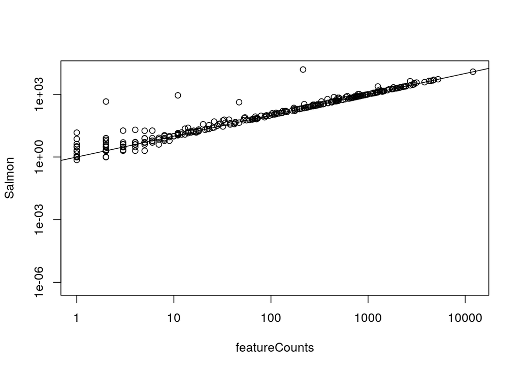

```r
plot(fc$counts, txi$counts[match(rownames(fc$counts), rownames(txi$counts))],
     log = "xy", xlab = "featureCounts", ylab = "Salmon")
abline(0, 1)
```

## Differential gene expression

### Load counts and tx2gene mapping for full data set

```r
dirs <- list.files(paste0(data_dir, "/airway_full/salmon"), full.names = TRUE)
files <- paste0(dirs, "/quant.sf")
names(files) <- basename(dirs)
files
```

```
##                                                              SRR1039508
## "/home/mholub/RNAseq_temp/input/airway_full/salmon/SRR1039508/quant.sf"
##                                                              SRR1039509
## "/home/mholub/RNAseq_temp/input/airway_full/salmon/SRR1039509/quant.sf"
##                                                              SRR1039512
## "/home/mholub/RNAseq_temp/input/airway_full/salmon/SRR1039512/quant.sf"
##                                                              SRR1039513
## "/home/mholub/RNAseq_temp/input/airway_full/salmon/SRR1039513/quant.sf"
##                                                              SRR1039516
## "/home/mholub/RNAseq_temp/input/airway_full/salmon/SRR1039516/quant.sf"
##                                                              SRR1039517
## "/home/mholub/RNAseq_temp/input/airway_full/salmon/SRR1039517/quant.sf"
##                                                              SRR1039520
## "/home/mholub/RNAseq_temp/input/airway_full/salmon/SRR1039520/quant.sf"
##                                                              SRR1039521
## "/home/mholub/RNAseq_temp/input/airway_full/salmon/SRR1039521/quant.sf"
```

```r
tx2gene <- readRDS(paste0(data_dir, "/airway_full/Homo_sapiens.GRCh37.75.cdna.ncrna.tx2gene.rds"))
txi <- tximport(files = files, type = "salmon", tx2gene = tx2gene)#, dropInfReps = TRUE)
```

```
## reading in files
```

```
## 1 2 3 4 5 6 7 8
## summarizing abundance
## summarizing counts
## summarizing length
```

```r
head(txi$counts)
```

```
##                 SRR1039508 SRR1039509 SRR1039512 SRR1039513 SRR1039516
## ENSG00000000003  692.89077  450.89420  886.92397   415.5883  1148.4205
## ENSG00000000005    0.00000    0.00000    0.00000     0.0000     0.0000
## ENSG00000000419  465.99992  515.00000  622.99960   363.9998   590.0000
## ENSG00000000457  325.51800  273.52481  371.34721   223.2042   354.3088
## ENSG00000000460   90.75704   75.96524   60.92455    49.0673   110.9532
## ENSG00000000938    0.00000    0.00000    2.00000     0.0000     1.0000
##                 SRR1039517 SRR1039520 SRR1039521
## ENSG00000000003 1069.48130   774.1766  580.95807
## ENSG00000000005    0.00000     0.0000    0.00000
## ENSG00000000419  794.00010   419.0003  509.99987
## ENSG00000000457  449.37030   308.6727  294.03507
## ENSG00000000460   95.44096   100.3721   82.90006
## ENSG00000000938    0.00000     0.0000    0.00000
```

```r
colSums(txi$counts)
```

```
## SRR1039508 SRR1039509 SRR1039512 SRR1039513 SRR1039516 SRR1039517
##   21377634   19532440   26333134   15813822   25430620   32133081
## SRR1039520 SRR1039521
##   19878529   22091297
```

### Generate DGEList

The `DGEList` (of [edgeR](http://bioconductor.org/packages/release/bioc/html/edgeR.html)) stores all necessary information about the experiment in a single object, which makes it easier to keep track and offers control mechanisms. Other packages use other objects (e.g., DESeqDataSet for [DESeq2](http://bioconductor.org/packages/release/bioc/html/DESeq2.html))

```r
suppressPackageStartupMessages(library(edgeR))
dge <- DGEList(counts = txi$counts, genes = data.frame(gene.id = rownames(txi$counts)))
dge
```

```
## An object of class "DGEList"
## $counts
##                 SRR1039508 SRR1039509 SRR1039512 SRR1039513 SRR1039516
## ENSG00000000003  692.89077  450.89420  886.92397   415.5883  1148.4205
## ENSG00000000005    0.00000    0.00000    0.00000     0.0000     0.0000
## ENSG00000000419  465.99992  515.00000  622.99960   363.9998   590.0000
## ENSG00000000457  325.51800  273.52481  371.34721   223.2042   354.3088
## ENSG00000000460   90.75704   75.96524   60.92455    49.0673   110.9532
##                 SRR1039517 SRR1039520 SRR1039521
## ENSG00000000003 1069.48130   774.1766  580.95807
## ENSG00000000005    0.00000     0.0000    0.00000
## ENSG00000000419  794.00010   419.0003  509.99987
## ENSG00000000457  449.37030   308.6727  294.03507
## ENSG00000000460   95.44096   100.3721   82.90006
## 63672 more rows ...
##
## $samples
##            group lib.size norm.factors
## SRR1039508     1 21377634            1
## SRR1039509     1 19532440            1
## SRR1039512     1 26333134            1
## SRR1039513     1 15813822            1
## SRR1039516     1 25430620            1
## SRR1039517     1 32133081            1
## SRR1039520     1 19878529            1
## SRR1039521     1 22091297            1
##
## $genes
##           gene.id
## 1 ENSG00000000003
## 2 ENSG00000000005
## 3 ENSG00000000419
## 4 ENSG00000000457
## 5 ENSG00000000460
## 63672 more rows ...
```

### Add additional gene identifiers

```r
suppressPackageStartupMessages(library(biomaRt))
ensembl <- useMart(biomart = "ENSEMBL_MART_ENSEMBL",
                   dataset="hsapiens_gene_ensembl", host = "www.ensembl.org")
convtable <- getBM(ensembl, attributes = c("ensembl_gene_id", "entrezgene", "hgnc_symbol"),
                   filters = "ensembl_gene_id", values = as.character(dge$genes$gene.id))
dge$genes$symbol <- convtable$hgnc_symbol[match(dge$genes$gene.id, convtable$ensembl_gene_id)]
dge$genes$entrez <- convtable$entrezgene[match(dge$genes$gene.id, convtable$ensembl_gene_id)]

head(dge$genes)
```

```
##           gene.id   symbol entrez
## 1 ENSG00000000003   TSPAN6   7105
## 2 ENSG00000000005     TNMD  64102
## 3 ENSG00000000419     DPM1   8813
## 4 ENSG00000000457    SCYL3  57147
## 5 ENSG00000000460 C1orf112  55732
## 6 ENSG00000000938      FGR   2268
```

### Calculate normalization factors

```r
dge <- calcNormFactors(dge)
dge
```

```
## An object of class "DGEList"
## $counts
##                 SRR1039508 SRR1039509 SRR1039512 SRR1039513 SRR1039516
## ENSG00000000003  692.89077  450.89420  886.92397   415.5883  1148.4205
## ENSG00000000005    0.00000    0.00000    0.00000     0.0000     0.0000
## ENSG00000000419  465.99992  515.00000  622.99960   363.9998   590.0000
## ENSG00000000457  325.51800  273.52481  371.34721   223.2042   354.3088
## ENSG00000000460   90.75704   75.96524   60.92455    49.0673   110.9532
##                 SRR1039517 SRR1039520 SRR1039521
## ENSG00000000003 1069.48130   774.1766  580.95807
## ENSG00000000005    0.00000     0.0000    0.00000
## ENSG00000000419  794.00010   419.0003  509.99987
## ENSG00000000457  449.37030   308.6727  294.03507
## ENSG00000000460   95.44096   100.3721   82.90006
## 63672 more rows ...
##
## $samples
##            group lib.size norm.factors
## SRR1039508     1 21377634    1.0549380
## SRR1039509     1 19532440    1.0223841
## SRR1039512     1 26333134    0.9808586
## SRR1039513     1 15813822    0.9664008
## SRR1039516     1 25430620    1.0198656
## SRR1039517     1 32133081    0.9596133
## SRR1039520     1 19878529    1.0402069
## SRR1039521     1 22091297    0.9608075
##
## $genes
##           gene.id   symbol entrez
## 1 ENSG00000000003   TSPAN6   7105
## 2 ENSG00000000005     TNMD  64102
## 3 ENSG00000000419     DPM1   8813
## 4 ENSG00000000457    SCYL3  57147
## 5 ENSG00000000460 C1orf112  55732
## 63672 more rows ...
```

### Add additional metadata

```r
meta <- read.delim(paste0(data_dir, "/airway_full/airway_meta.txt"), header = TRUE, as.is = TRUE)
meta
```

```
##   SampleName    cell   dex albut        Run avgLength Experiment    Sample
## 1 GSM1275862  N61311 untrt untrt SRR1039508       126  SRX384345 SRS508568
## 2 GSM1275863  N61311   trt untrt SRR1039509       126  SRX384346 SRS508567
## 3 GSM1275866 N052611 untrt untrt SRR1039512       126  SRX384349 SRS508571
## 4 GSM1275867 N052611   trt untrt SRR1039513        87  SRX384350 SRS508572
## 5 GSM1275870 N080611 untrt untrt SRR1039516       120  SRX384353 SRS508575
## 6 GSM1275871 N080611   trt untrt SRR1039517       126  SRX384354 SRS508576
## 7 GSM1275874 N061011 untrt untrt SRR1039520       101  SRX384357 SRS508579
## 8 GSM1275875 N061011   trt untrt SRR1039521        98  SRX384358 SRS508580
##      BioSample
## 1 SAMN02422669
## 2 SAMN02422675
## 3 SAMN02422678
## 4 SAMN02422670
## 5 SAMN02422682
## 6 SAMN02422673
## 7 SAMN02422683
## 8 SAMN02422677
```

```r
dge$samples <- merge(dge$samples, meta[, c("Run", "cell", "dex")],
                     by.x = 0, by.y = "Run", all = TRUE)
dge$samples$dex <- relevel(factor(dge$samples$dex), ref = "untrt")
dge
```

```
## An object of class "DGEList"
## $counts
##                 SRR1039508 SRR1039509 SRR1039512 SRR1039513 SRR1039516
## ENSG00000000003  692.89077  450.89420  886.92397   415.5883  1148.4205
## ENSG00000000005    0.00000    0.00000    0.00000     0.0000     0.0000
## ENSG00000000419  465.99992  515.00000  622.99960   363.9998   590.0000
## ENSG00000000457  325.51800  273.52481  371.34721   223.2042   354.3088
## ENSG00000000460   90.75704   75.96524   60.92455    49.0673   110.9532
##                 SRR1039517 SRR1039520 SRR1039521
## ENSG00000000003 1069.48130   774.1766  580.95807
## ENSG00000000005    0.00000     0.0000    0.00000
## ENSG00000000419  794.00010   419.0003  509.99987
## ENSG00000000457  449.37030   308.6727  294.03507
## ENSG00000000460   95.44096   100.3721   82.90006
## 63672 more rows ...
##
## $samples
##    Row.names group lib.size norm.factors    cell   dex
## 1 SRR1039508     1 21377634    1.0549380  N61311 untrt
## 2 SRR1039509     1 19532440    1.0223841  N61311   trt
## 3 SRR1039512     1 26333134    0.9808586 N052611 untrt
## 4 SRR1039513     1 15813822    0.9664008 N052611   trt
## 5 SRR1039516     1 25430620    1.0198656 N080611 untrt
## 6 SRR1039517     1 32133081    0.9596133 N080611   trt
## 7 SRR1039520     1 19878529    1.0402069 N061011 untrt
## 8 SRR1039521     1 22091297    0.9608075 N061011   trt
##
## $genes
##           gene.id   symbol entrez
## 1 ENSG00000000003   TSPAN6   7105
## 2 ENSG00000000005     TNMD  64102
## 3 ENSG00000000419     DPM1   8813
## 4 ENSG00000000457    SCYL3  57147
## 5 ENSG00000000460 C1orf112  55732
## 63672 more rows ...
```

### Filter out lowly expressed genes

Different filter criteria are possible, but should be independent of the test statistic under the null hypothesis (in particular, should not involve use of the sample annotations).

```r
cpm <- cpm(dge)
dge <- dge[which(rowSums(cpm > 0.5) > 4), , keep.lib.sizes = FALSE]
dge <- calcNormFactors(dge)
```

### Estimate dispersion

```r
(design <- model.matrix(~cell + dex, data = dge$samples))
```

```
##   (Intercept) cellN061011 cellN080611 cellN61311 dextrt
## 1           1           0           0          1      0
## 2           1           0           0          1      1
## 3           1           0           0          0      0
## 4           1           0           0          0      1
## 5           1           0           1          0      0
## 6           1           0           1          0      1
## 7           1           1           0          0      0
## 8           1           1           0          0      1
## attr(,"assign")
## [1] 0 1 1 1 2
## attr(,"contrasts")
## attr(,"contrasts")$cell
## [1] "contr.treatment"
##
## attr(,"contrasts")$dex
## [1] "contr.treatment"
```

```r
dge <- estimateDisp(dge, design = design)
dge
```

```
## An object of class "DGEList"
## $counts
##                 SRR1039508 SRR1039509 SRR1039512 SRR1039513 SRR1039516
## ENSG00000000003  692.89077  450.89420  886.92397   415.5883  1148.4205
## ENSG00000000419  465.99992  515.00000  622.99960   363.9998   590.0000
## ENSG00000000457  325.51800  273.52481  371.34721   223.2042   354.3088
## ENSG00000000460   90.75704   75.96524   60.92455    49.0673   110.9532
## ENSG00000000971 3292.11281 3741.34146 6130.25970  4252.0062  6679.7295
##                  SRR1039517 SRR1039520 SRR1039521
## ENSG00000000003  1069.48130   774.1766  580.95807
## ENSG00000000419   794.00010   419.0003  509.99987
## ENSG00000000457   449.37030   308.6727  294.03507
## ENSG00000000460    95.44096   100.3721   82.90006
## ENSG00000000971 10969.18035  5066.0030 7881.99520
## 16381 more rows ...
##
## $samples
##    Row.names group lib.size norm.factors    cell   dex
## 1 SRR1039508     1 21313855    1.0572776  N61311 untrt
## 2 SRR1039509     1 19476562    1.0240624  N61311   trt
## 3 SRR1039512     1 26256722    0.9886396 N052611 untrt
## 4 SRR1039513     1 15771498    0.9475149 N052611   trt
## 5 SRR1039516     1 25351189    1.0319268 N080611 untrt
## 6 SRR1039517     1 32040642    0.9696286 N080611   trt
## 7 SRR1039520     1 19803041    1.0311183 N061011 untrt
## 8 SRR1039521     1 22020883    0.9556475 N061011   trt
##
## $genes
##           gene.id   symbol entrez
## 1 ENSG00000000003   TSPAN6   7105
## 3 ENSG00000000419     DPM1   8813
## 4 ENSG00000000457    SCYL3  57147
## 5 ENSG00000000460 C1orf112  55732
## 7 ENSG00000000971      CFH   3075
## 16381 more rows ...
##
## $design
##   (Intercept) cellN061011 cellN080611 cellN61311 dextrt
## 1           1           0           0          1      0
## 2           1           0           0          1      1
```

[output cut: 27 more lines]

```
## $AveLogCPM
## [1] 5.024461 4.557901 3.847244 1.916873 8.026707
## 16381 more elements ...
##
## $trend.method
## [1] "locfit"
##
## $prior.df
## [1] 3.842073
##
## $prior.n
## [1] 1.280691
##
## $span
## [1] 0.2914295
```

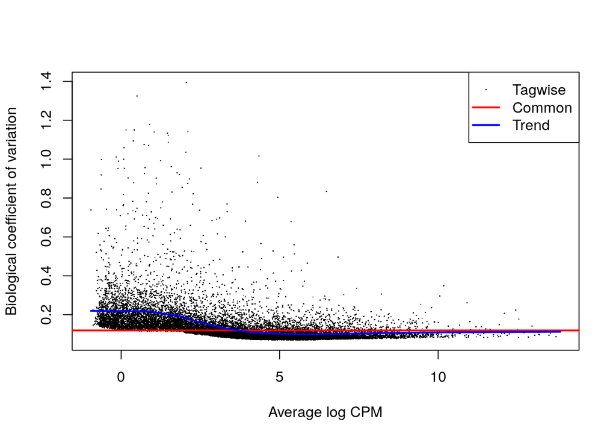

```r
plotBCV(dge)
```

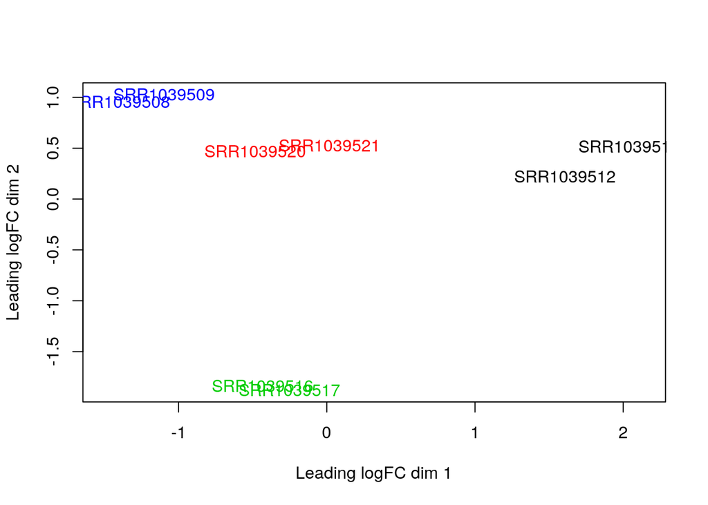

```r
plotMDS(dge, col = as.numeric(factor(dge$samples$cell)))
```

### Fit model and test

```r
## Quasi-likelihood test
fit <- glmQLFit(dge, design = design, robust = TRUE)
qlf <- glmQLFTest(fit, coef = "dextrt")

## Alt: Likelihood ratio test
## fit <- glmFit(dge, design = design)
## lrt <- glmLRT(fit, coef = "dextrt")

tt <- topTags(qlf, n = Inf)
head(tt$table)
```

```
##               gene.id symbol entrez     logFC   logCPM         F
## 3751  ENSG00000109906 ZBTB16   7704  5.615869 4.127101 1582.5809
## 11864 ENSG00000165995 CACNB2    783  3.312452 4.610381 1582.2717
## 8911  ENSG00000146250 PRSS35 167681 -2.749471 3.863704  926.6459
## 10867 ENSG00000162493   PDPN  10630  1.869010 5.627208  916.3819
## 9929  ENSG00000154930  ACSS1  84532  1.882222 4.917135  769.0795
## 10186 ENSG00000157214 STEAP2 261729  1.953279 7.086805  740.2884
##             PValue          FDR
## 3751  7.872639e-10 6.454652e-06
## 11864 7.878253e-10 6.454652e-06
## 8911  5.534250e-09 2.360847e-05
## 10867 5.763084e-09 2.360847e-05
## 9929  1.089688e-08 3.260523e-05
## 10186 1.251655e-08 3.260523e-05
```

### Write results to file

```r
write.table(tt$table, file = paste0(output_dir, "/DGE_results_edgeR.txt"),
            row.names = FALSE, col.names = TRUE, quote = FALSE, sep = "\t")
```

### Diagnostics: p-value histogram

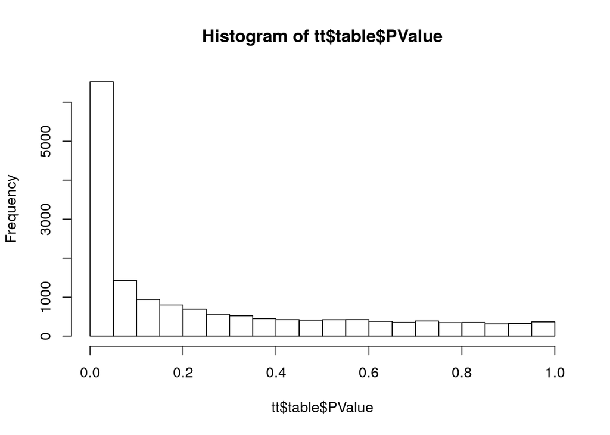

```r
hist(tt$table$PValue)
```

### Find differentially expressed genes

```r
is.de <- decideTestsDGE(qlf, p.value = 0.05)
summary(is.de)
```

```
##    [,1]
## -1  2151
## 0  11875
## 1   2360
```

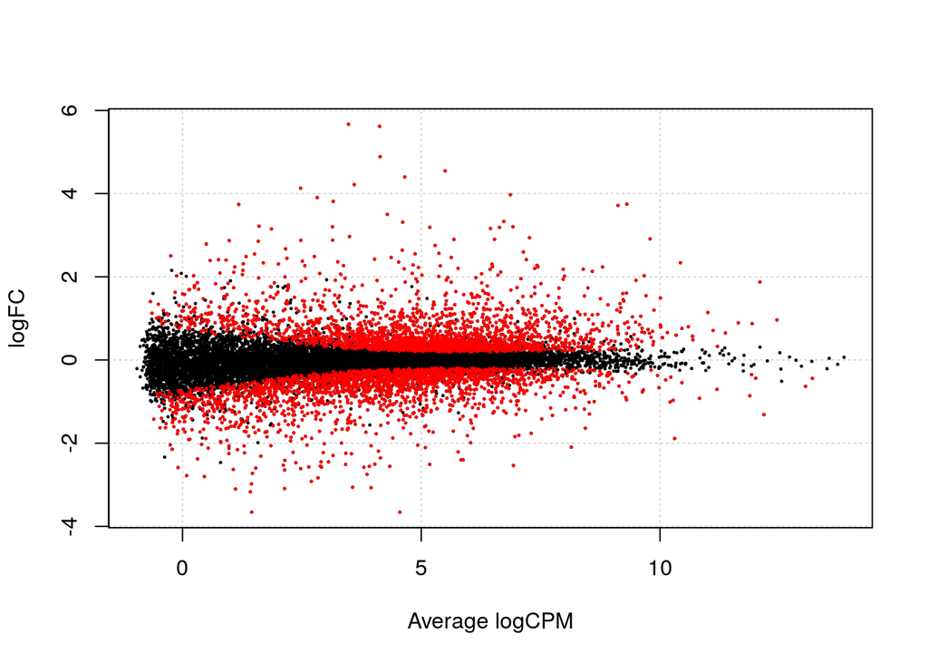

```r
plotSmear(qlf, de.tags = rownames(qlf)[is.de != 0])
```

### Visualize a few of the differentially expressed genes

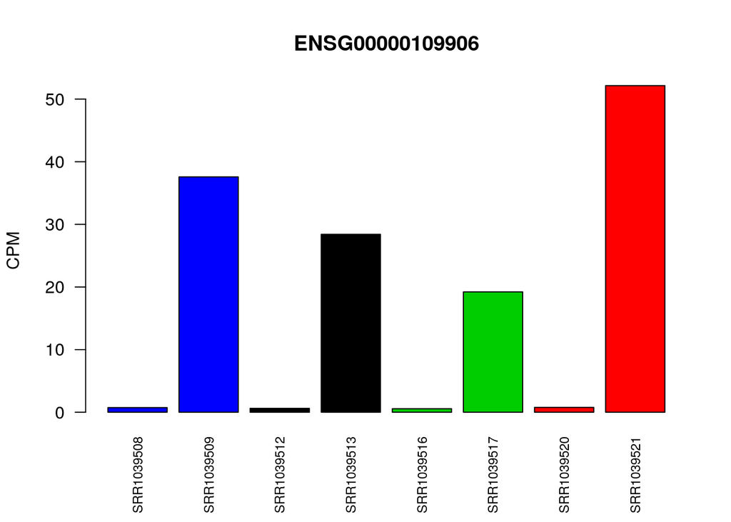

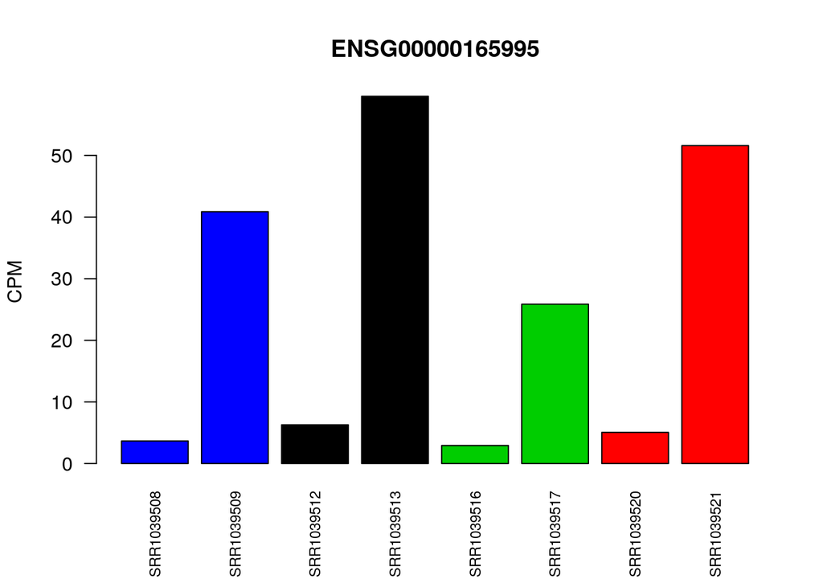

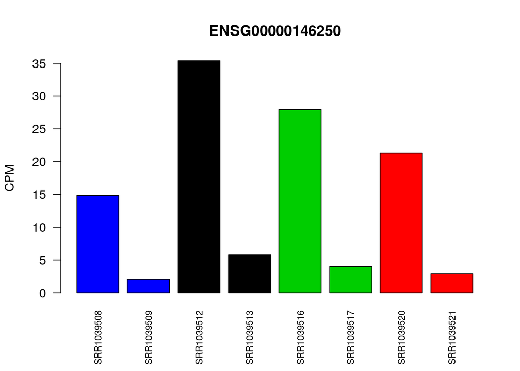

```r
for (i in tt$table$gene.id[1:3]) {
  barplot(cpm[i, ], col = as.numeric(factor(dge$samples$cell)),
          las = 2, cex.names = 0.75, main = i, ylab = "CPM")
}
```

## Gene set analysis (functional analysis)

Gene sets represent groups of genes that are “related” in some (well-defined) way. They can be obtained e.g. from [mSigDB](http://software.broadinstitute.org/gsea/msigdb/), [GO (Gene Ontology)](http://geneontology.org/), [KEGG](http://www.genome.jp/kegg/). There is an important distinction between *competitive* and *self-contained* gene set analysis tests ([Goeman & B??hlmann](http://bioinformatics.oxfordjournals.org/content/23/8/980)).

```r
hallmarks <- readRDS(paste0(data_dir, "/hallmarks_entrez.rds"))
head(hallmarks)
```

```
## $HALLMARK_TNFA_SIGNALING_VIA_NFKB
##   [1]   3726   2920    467   4792   7128   5743   2919   8870   9308   6364
##  [11]   2921  23764   4791   7127   1839   1316    330   5329   7538   3383
##  [21]   3725   1960   3553    597  23645  80149   6648   4929   3552   5971
##  [31]   7185   7832   1843   1326   2114   2152   6385   1958   3569   7124
##  [41]  23135   4790   3976   5806   8061   3164    182   6351   2643   6347
##  [51]   1827   1844  10938   9592   5966   8837   8767   4794   8013  22822
##  [61]  51278   8744   2669   1647   3627  10769   8553   1959   9021  11182
##  [71]   5734   1847   5055   4783   5054  10221  25976   5970    329   6372
##  [81]   9516   7130    960   3624   5328   4609   3604   6446  10318  10135
##  [91]   2355  10957   3398    969   3575   1942   7262   5209   6352  79693
## [101]   3460   8878  10950   4616   8942  50486    694   4170   7422   5606
## [111]   1026   3491  10010   3433   3606   7280   3659   2353   4973    388
## [121]    374   4814  65986   8613   9314   6373   6303   1435   1880  56937
## [131]   5791   7097  57007   7071   4082   3914   1051   9322   2150    687
```

[output cut: 73 more lines]

```r
dge$counts <- round(dge$counts)
gstest <- camera(dge, index = ids2indices(hallmarks, dge$genes$entrez), design = design)
gstest
```

```
##                                            NGenes Direction       PValue
## HALLMARK_ADIPOGENESIS                         190        Up 0.0000487067
## HALLMARK_ANDROGEN_RESPONSE                     91        Up 0.0018262333
## HALLMARK_TNFA_SIGNALING_VIA_NFKB              178        Up 0.0081912325
## HALLMARK_P53_PATHWAY                          189      Down 0.0135921519
## HALLMARK_E2F_TARGETS                          206      Down 0.0356266922
## HALLMARK_REACTIVE_OXIGEN_SPECIES_PATHWAY       49        Up 0.0372482516
## HALLMARK_UV_RESPONSE_DN                       143        Up 0.0402644329
## HALLMARK_OXIDATIVE_PHOSPHORYLATION            201        Up 0.0415444957
## HALLMARK_COMPLEMENT                           152        Up 0.0438368592
## HALLMARK_INTERFERON_ALPHA_RESPONSE            106      Down 0.0479400293
## HALLMARK_FATTY_ACID_METABOLISM                136        Up 0.0484693127
## HALLMARK_HEDGEHOG_SIGNALING                    27      Down 0.0545788126
## HALLMARK_IL2_STAT5_SIGNALING                  157        Up 0.0555236830
## HALLMARK_WNT_BETA_CATENIN_SIGNALING            36        Up 0.0665613967
## HALLMARK_ANGIOGENESIS                          26      Down 0.0748833814
## HALLMARK_UV_RESPONSE_UP                       147        Up 0.0794874390
## HALLMARK_HYPOXIA                              177        Up 0.1059450835
## HALLMARK_MYC_TARGETS_V2                        57        Up 0.1105991305
## HALLMARK_PROTEIN_SECRETION                     91        Up 0.1199264979
## HALLMARK_XENOBIOTIC_METABOLISM                166        Up 0.1288854638
## HALLMARK_BILE_ACID_METABOLISM                  82        Up 0.1369143917
## HALLMARK_INTERFERON_GAMMA_RESPONSE            208      Down 0.1663666878
## HALLMARK_CHOLESTEROL_HOMEOSTASIS               68        Up 0.1752214670
## HALLMARK_MYC_TARGETS_V1                       209        Up 0.2316218952
## HALLMARK_INFLAMMATORY_RESPONSE                139        Up 0.2370513885
## HALLMARK_IL6_JAK_STAT3_SIGNALING               60        Up 0.2380936386
## HALLMARK_MTORC1_SIGNALING                     193      Down 0.2888255293
## HALLMARK_MITOTIC_SPINDLE                      193        Up 0.3150732776
## HALLMARK_APICAL_JUNCTION                      162        Up 0.3195252239
## HALLMARK_UNFOLDED_PROTEIN_RESPONSE            111        Up 0.3293358097
## HALLMARK_PEROXISOME                            87        Up 0.4217635990
## HALLMARK_TGF_BETA_SIGNALING                    52        Up 0.4436780905
## HALLMARK_ESTROGEN_RESPONSE_EARLY              160        Up 0.4453217706
## HALLMARK_ALLOGRAFT_REJECTION                  150      Down 0.4667635275
## HALLMARK_DNA_REPAIR                           155      Down 0.4836963967
## HALLMARK_KRAS_SIGNALING_UP                    143      Down 0.5375332804
## HALLMARK_COAGULATION                           98        Up 0.6420747176
## HALLMARK_EPITHELIAL_MESENCHYMAL_TRANSITION    193      Down 0.6567024989
## HALLMARK_PANCREAS_BETA_CELLS                   19        Up 0.7367769074
```

[output cut: 47 more lines]

```
## HALLMARK_KRAS_SIGNALING_UP                 0.746574000
## HALLMARK_COAGULATION                       0.864082235
## HALLMARK_EPITHELIAL_MESENCHYMAL_TRANSITION 0.864082235
## HALLMARK_PANCREAS_BETA_CELLS               0.905138138
## HALLMARK_NOTCH_SIGNALING                   0.905138138
## HALLMARK_ESTROGEN_RESPONSE_LATE            0.905138138
## HALLMARK_APICAL_SURFACE                    0.905138138
## HALLMARK_G2M_CHECKPOINT                    0.905138138
## HALLMARK_KRAS_SIGNALING_DN                 0.907036238
## HALLMARK_MYOGENESIS                        0.944618176
## HALLMARK_PI3K_AKT_MTOR_SIGNALING           0.944618176
## HALLMARK_HEME_METABOLISM                   0.944618176
## HALLMARK_SPERMATOGENESIS                   0.944618176
## HALLMARK_GLYCOLYSIS                        0.952212312
## HALLMARK_APOPTOSIS                         0.983661827
```

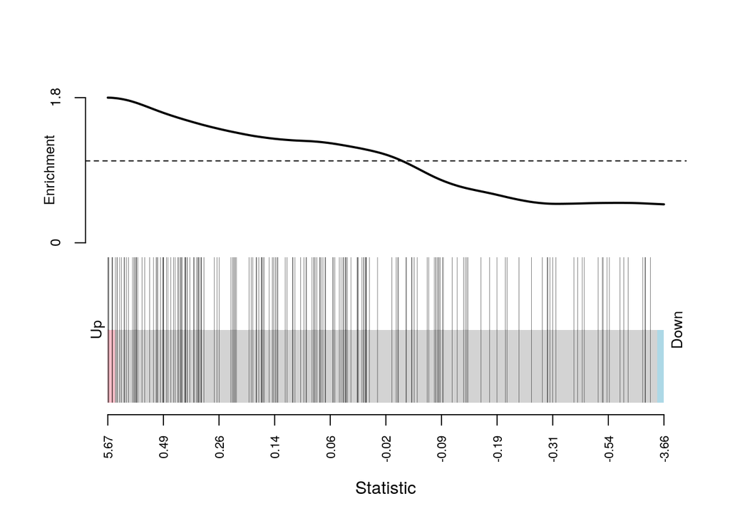

```r
barcodeplot(qlf$table$logFC,
            index = ids2indices(hallmarks, dge$genes$entrez)[["HALLMARK_ADIPOGENESIS"]])
```